# Making reproducible documents with R

## Session details

  ```r
  install.packages(c("dplyr", "tidyr"))
  # Or just use install tidyverse
  # install.packages("tidyverse")
  ```

### Objectives

1. To learn how to generate high quality reports that can be shared with an broad audience.
2. To create reproducible scripts that can be run with different data sets.
3. To use Rstudio not as a data science tool but also as a text editor and compiler!

**At the end of this session you will be able**:

1. To learn about markdown syntax.
2. To combine text and code in the same document.
3. To include tables, figures, links and references to your document.
4. To create your first report with Rmarkdown.

## Resources for learning and help

**For learning**:

1. [RStudio tutorial on using RMarkdown](https://rmarkdown.rstudio.com/lesson-1.html)
2. [Markdown syntax guide](https://rmarkdown.rstudio.com/authoring_basics.html)

**For help**:

- [RStudio helpful cheatsheets](https://www.rstudio.com/resources/cheatsheets/)
- [R Markdown cheatsheet](https://github.com/rstudio/cheatsheets/raw/master/rmarkdown-2.0.pdf)
- [R Markdown reference cheatsheet](https://www.rstudio.com/wp-content/uploads/2015/03/rmarkdown-reference.pdf)

## Quickly get familiar with the markdown syntax

### Markdown syntax

Headers (like section, subsection, subsubsection, etc):

> `# Header 1`

> gives…

# Header 1

> `## Header 2`

> gives…

## Header 2

> `### Header 3`

> gives…

### Header 3

> `**bold**` gives **bold**. `*italics*` gives *italics*.

> ```
> Unnumbered list:
>
> - item 1
> - item 2
> - item 3
> ```

> gives…

> Unnumbered list:
> - item 1
> - item 2
> - item 3

> ```
> Numbered list:
> Z
> 1. item 1
> 2. item 2
> 3. item 3
> ```

> gives…

> Numbered list:
> 1. item 1
> 2. item 2
> 3. item 3

#### Exercise 1: construct a sketch for a paper

Time: 10 min

Open RStudio and create an `Rmarkdown document`:

**File -> New File -> R Markdown**

Create a RMarkdown document containing the following structure:

- Abstract
- Introduction
- Results
- Material and Methods
- Discussion
- Conclusion

Compile it by pressing the icon `Knit to HTML`

Now, try to write some information just below the **abstract section** (try to include some numbered and unumbered lists, bold and italic words in this text). Compile the document again and see what happens.

### Adding footnotes, pictures and links to your document

Footnotes can be done using the following command:

> ```
> Footnote[^1]
>
> [^1]: Footnote content
> ```

> Footnote[^1]

A .png .jpeg or .pdf image can be attached in the following way:

> ```
> ![image caption](images/au_coders.jpeg)
> ```

> gives…

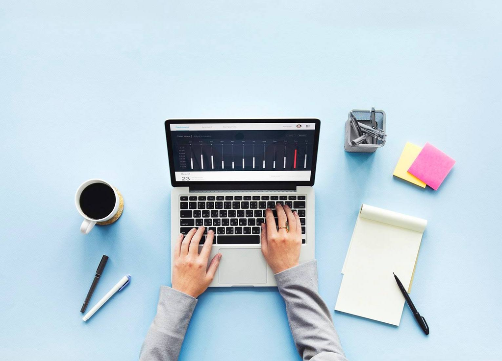

> image caption

And a link can be linked in the following format:

> ```
> [Link](https://google.com)
> ```

> gives…

> [Link](https://google.com)

One can also create quotes:

> ```
> > Block quote
> ```

> gives…

> > Block quote

#### Exercise 2: hands on!

Time: 10 min

Now you are asked to include in your “skecthed article” what we just have learned.

1. Include a picture with caption (of your research, or any .png you find in your PC).
2. Include a footnote.
3. Include the link of au.code webpage to your document.

### R code in Markdown

One of the most powerful and useful features of Rmarkdown, is its ability to combine text and code in the same document! You can insert plots by including a code chunk like below:

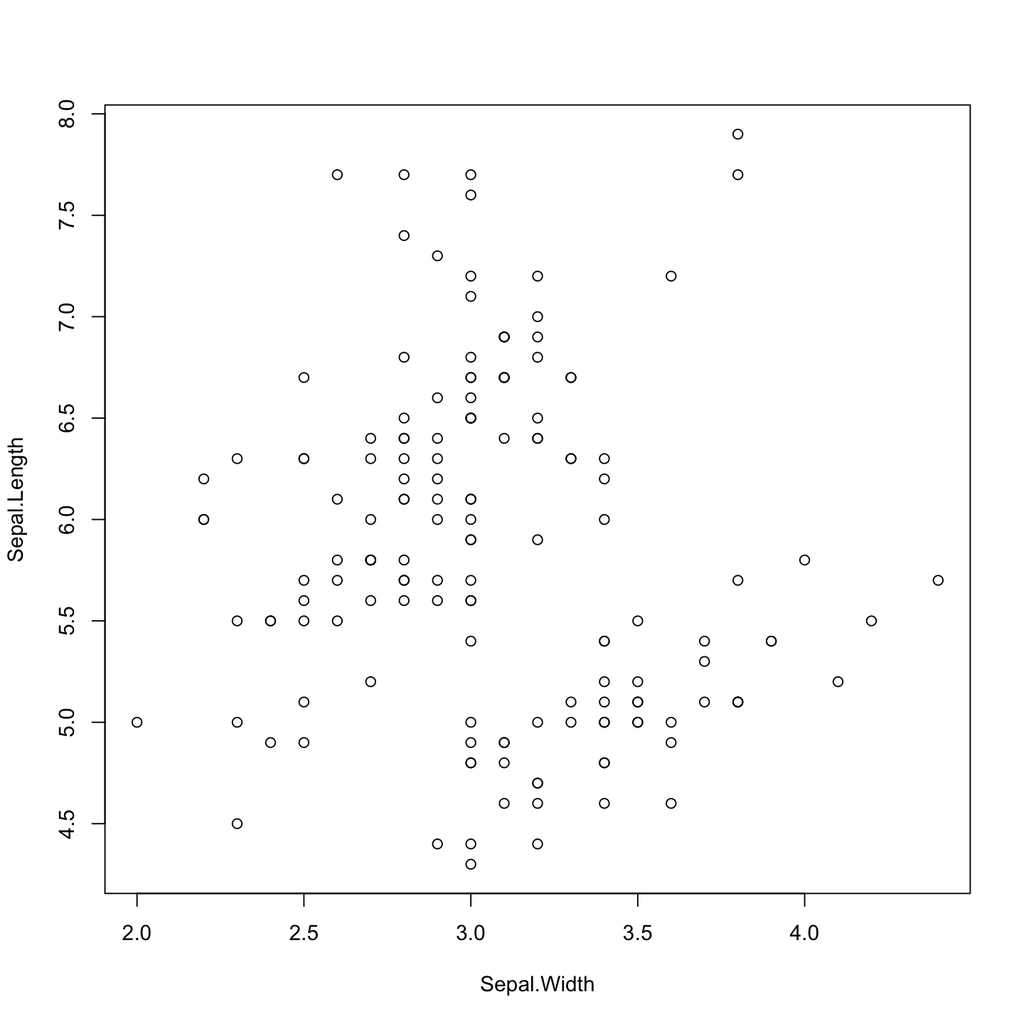

Figure title here

````markdown
```{r plot_sepal, fig.cap="Figure title here", fig.height=8, fig.width=8, echo=FALSE}
plot(Sepal.Length ~ Sepal.Width, data = iris)
```
````

… The options added to the code chunk tell it to add a caption, and set the height and width of the figure.

You can also create tables by using the `kable()` in the knitr package.

````markdown
```{r}
knitr::kable(head(iris), caption = "Table caption here")
```
````

Table caption here

| Sepal.Length | Sepal.Width | Petal.Length | Petal.Width | Species |
| --- | --- | --- | --- | --- |
| 5.1 | 3.5 | 1.4 | 0.2 | setosa |
| 4.9 | 3.0 | 1.4 | 0.2 | setosa |
| 4.7 | 3.2 | 1.3 | 0.2 | setosa |
| 4.6 | 3.1 | 1.5 | 0.2 | setosa |
| 5.0 | 3.6 | 1.4 | 0.2 | setosa |
| 5.4 | 3.9 | 1.7 | 0.4 | setosa |

For small not complex tables, one can also create it outside of a R chunck using the markdown syntex: This:

```
|       &nbsp;       | diverged | polymorphic |
|:------------------:|:--------:|:-----------:|
|   **synonymous**   |   1300   |    2109     |
| **non-synonymous** |   700    |     891     |
```

gives…

|  | diverged | polymorphic |
| --- | --- | --- |
| **synonymous** | 1300 | 2109 |
| **non-synonymous** | 700 | 891 |

You can hide the code chunk but keep the output by using the `echo=FALSE` option:

````markdown
```{r, echo=FALSE}
model <- lm(Sepal.Length ~ Sepal.Width, data = iris)
coef(model)
```
````

```
#> (Intercept) Sepal.Width
#>   6.5262226  -0.2233611
```

#### Exercise 3: adding plots and tables to your results section

Time: 10 min

You now need to create a chunck of code in the **Results section**. If you have any plot from your own research that you want to create feel free to do it so. Otherwise you can just use the iris data:

1. Plot Sepal.length versus Sepal.Width. Include a caption and choose 6 X 10 dimensions.
2. Print a table with the mean and sd of each column of the iris dataset. Remember to output just the table and not the code! Use the following code:

```
#install.packages("dplyr")
library(dplyr)
iris %>%
  group_by_("Species") %>%
  summarise_each_(funs=funs("mean", "sd"), vars=c("Sepal.Length", "Sepal.Width"))
```

3. Create a small table (2 columns) outside of the R chunk.

### Inline R codes and the power of citing with Rmarkdown

Now that you have learned how to plots and tables to your results section, it is time to go to the **Discussion section**. A powerful feature of R markdown is its syntex simplicity.

You can use for example a inline R code too, to insert numbers directly into the document.

Use this: The estimate is `` `r round(coef(model)[2], 2)` ``… to get this: The estimate is -0.22.

If you want to insert a citation use `[@Hoejsgaard2006a]` to get it to look like: (Højsgaard, Halekoh, and Yan 2006)… the reference is inserted onto the bottom of the document. You need to add a line like this `bibliography: bibfile.bib` to the top YAML header (e.g. right below where you put the `title` and `author`)

#### Exercise 4: quick R calculations and inserting citations to your document

Time: Until end of session

Now you are asked:

1. To calculate the correlation between Sepal.Length and Sepal.Width inline (outside of the R chunck).
2. To create a new document (in the same directory as this document is placed) and include a reference of the paper you most like!
3. Cite this paper in the **discussion section** of your document.
4. Compile it again, and see what happens!

We hope we have convincend you that Rmarkdown is a powerful tool for reproducibility and for creating pretty reports! Chuncks can also compile different languages than R, making life easier!

# References (add this to separate the ref list)

Højsgaard, Søren, Ulrich Halekoh, and Jun Yan. 2006. “The R Package Geepack for Generalized Estimating Equations.” *Journal of Statistical Software* 15/2: 1–11.

[^1]: Footnote content